# `pymclustR` vs CRAN `mclust` — clustering & consistency comparison

## 4. Side-by-side cluster scatters

Pick the (G, model) that R chose by BIC for each dataset, then plot the 2-D projection coloured by R-cls vs Python-cls.

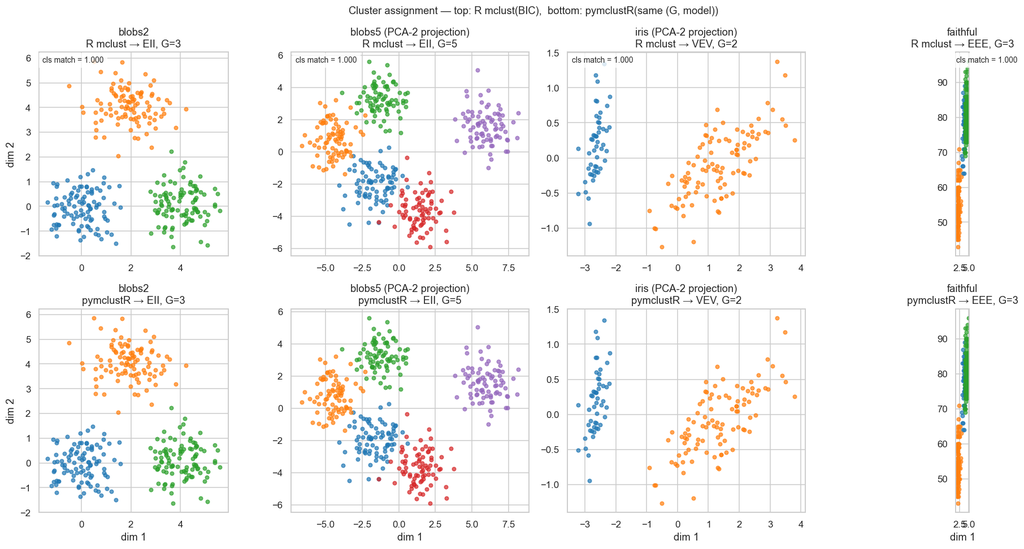

```python
fig, axes = plt.subplots(2, 4, figsize=(18, 9))
for col, ds in enumerate(DATASETS):
    full_path = DUMP / f'mclust_full_{ds}.json'
    if not full_path.exists(): continue
    full = json.loads(full_path.read_text())
    X = load_csv(DUMP / f'data_{ds}_X.csv')
    mname = full['modelName']
    G = int(full['G'])
    r_cls = np.array(full['classification'])
    # Run pymclustR with the same (G, model)
    z_init = load_csv(DUMP / f'zinit_{ds}_G{G}.csv') if (DUMP / f'zinit_{ds}_G{G}.csv').exists() else None
    if z_init is not None and z_init.shape[1] >= G:
        out = me(X, mname, z_init[:, :G])
    else:
        from mclust_py import Mclust
        out = Mclust(X, G=[G], model_names=[mname])
        out = out.em_result
    py_cls = np.argmax(out.z, axis=1) + 1
    if X.shape[1] > 2:
        # PCA-2 for visualisation only
        from sklearn.decomposition import PCA
        Xv = PCA(n_components=2, random_state=0).fit_transform(X)
        sub = ' (PCA-2 projection)'
    else:
        Xv, sub = X, ''
    palette = sns.color_palette('tab10', n_colors=max(G, 3))
    for ax_row, cls, label in [(0, r_cls, 'R mclust'), (1, py_cls, 'pymclustR')]:
        ax = axes[ax_row, col]
        for k in np.unique(cls):
            m = cls == k
            ax.scatter(Xv[m, 0], Xv[m, 1], s=18, alpha=0.7,
                       color=palette[(int(k)-1) % len(palette)], label=f'cluster {k}')
        ax.set_title(f'{ds}{sub}\n{label} → {mname}, G={G}')
        ax.set_aspect('equal' if ds in {'blobs2','faithful'} else 'auto')
        if ax_row == 1: ax.set_xlabel('dim 1')
        ax.set_ylabel('dim 2' if col == 0 else '')
    # Annotate top row with classification agreement
    match = aligned_match(r_cls, py_cls, G)
    axes[0, col].text(0.02, 0.98, f'cls match = {match:.3f}',
                      transform=axes[0, col].transAxes,
                      ha='left', va='top', fontsize=9,
                      bbox=dict(facecolor='white', alpha=0.8, edgecolor='none'))
plt.suptitle('Cluster assignment — top: R mclust(BIC),  bottom: pymclustR(same (G, model))', fontsize=12)
plt.tight_layout()
plt.show()
```

## 5. BIC curves — model selection comparison

For each dataset, plot R's full `mclustBIC` matrix alongside the pymclustR BIC values (rebuilt from the per-record loglik in `df` plus the `n_mclust_params` formula — same definition R uses).

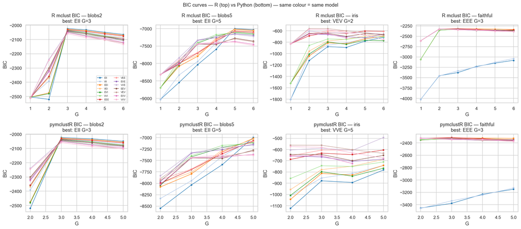

```python
from mclust_py.bic import n_mclust_params

def py_bic_table(df_sub):
    rows = []
    for _, r in df_sub.iterrows():
        k = n_mclust_params(r['modelName'], int(r['d']), int(r['G']))
        rows.append({'modelName': r['modelName'], 'G': r['G'],
                     'BIC': 2.0 * r['py_loglik'] - k * np.log(r['n'])})
    return (pd.DataFrame(rows)
              .pivot_table(index='G', columns='modelName', values='BIC')
              .reindex(columns=MODELS))

fig, axes = plt.subplots(2, 4, figsize=(18, 8))
palette = sns.color_palette('tab20', n_colors=14)
color_map = dict(zip(MODELS, palette))
for col, ds in enumerate(DATASETS):
    full_path = DUMP / f'mclust_full_{ds}.json'
    if not full_path.exists(): continue
    full = json.loads(full_path.read_text())
    Gs_R = full['BIC_dimnames_G']
    models_R = full['BIC_dimnames_model']
    BIC_R = reshape_F(full['BIC'], full['BIC_dim'])
    BIC_R = pd.DataFrame(BIC_R, index=Gs_R, columns=models_R)
    BIC_py = py_bic_table(df[df['dataset'] == ds])

    ax = axes[0, col]
    for m in models_R:
        ax.plot(BIC_R.index, BIC_R[m], marker='o', ms=3, lw=1,
                color=color_map.get(m, '#888'), label=m)
    ax.set_title(f'R mclust BIC — {ds}\nbest: {full["modelName"]} G={full["G"]}')
    ax.set_xlabel('G'); ax.set_ylabel('BIC')
    if col == 0: ax.legend(ncol=2, fontsize=6, loc='lower right')

    ax = axes[1, col]
    best = BIC_py.stack().idxmax()
    for m in BIC_py.columns:
        ax.plot(BIC_py.index, BIC_py[m], marker='s', ms=3, lw=1,
                color=color_map.get(m, '#888'), label=m)
    ax.set_title(f'pymclustR BIC — {ds}\nbest: {best[1]} G={best[0]}')
    ax.set_xlabel('G'); ax.set_ylabel('BIC')

plt.suptitle('BIC curves — R (top) vs Python (bottom) — same colour = same model', fontsize=12)
plt.tight_layout()
plt.show()
```

## 6. Confusion matrix — per-dataset hard-label agreement

For each dataset we take the *best* (G, model) chosen by R, run `pymclustR` with the same configuration, and tabulate label agreement.

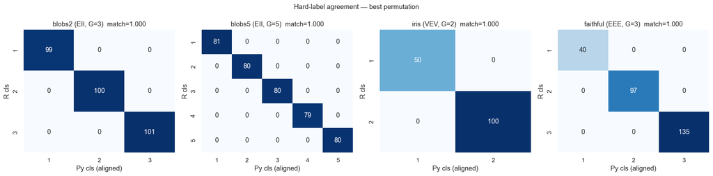

```python
fig, axes = plt.subplots(1, 4, figsize=(18, 4.5))
for ax, ds in zip(axes, DATASETS):
    full_path = DUMP / f'mclust_full_{ds}.json'
    if not full_path.exists(): continue
    full = json.loads(full_path.read_text())
    X = load_csv(DUMP / f'data_{ds}_X.csv')
    G = int(full['G'])
    mname = full['modelName']
    r_cls = np.array(full['classification'])
    z_init = load_csv(DUMP / f'zinit_{ds}_G{G}.csv')[:, :G]
    out = me(X, mname, z_init)
    py_cls = np.argmax(out.z, axis=1) + 1
    # Best label permutation
    best, best_perm_lst = -1, None
    for perm in permutations(range(1, G + 1)):
        rl = np.array([0] + list(perm))
        m = float(np.mean(rl[py_cls] == r_cls))
        if m > best: best, best_perm_lst = m, perm
    relabel = np.array([0] + list(best_perm_lst))
    py_aligned = relabel[py_cls]
    cm = pd.crosstab(pd.Series(r_cls, name='R cls'),
                     pd.Series(py_aligned, name='Py cls (aligned)'))
    sns.heatmap(cm, annot=True, fmt='d', cmap='Blues', ax=ax, cbar=False)
    ax.set_title(f'{ds} ({mname}, G={G})  match={best:.3f}')
plt.suptitle('Hard-label agreement — best permutation', fontsize=12)
plt.tight_layout()
plt.show()
```